# Lasso Regression on Cellphone Use Addiction

Author

Richard Odgers, Melissa Bolen, Jillian Mouser, Jonathan De La Torre (Advisor: Dr. Cohen)

Published

July 22, 2026

Slides: slides.html

## Introduction

In today’s ever-growing digital era, what began as a tool of convenience, smartphones and devices have become a vital piece of our daily life. While these items enable instant communication across the globe, growing usage has evolved into an increasing psychological and social crisis: smartphone addiction, known formally in literature as Problematic Smartphone Use (PSU). Characterized by the compulsive need to check notifications and apps, withdrawal symptoms, and severe interference with daily life, smartphone dependency shows an increasing link to rising rates of anxiety, sleep deprivation, and diminished academic performance among young adults (Lin et al. 2014). A comprehensive systematic review of 293 global studies establishes that problematic smartphone usage is heavily driven by poor impulse control and negative emotional health, finding that young, female populations are statistically the most vulnerable to developing these dependencies (Busch and McCarthy 2021). Identifying the precise behavioral, social, and psychological drivers of this addiction is critical for developing effective interventions. Available data tracking screen time, app usage, and psychological metrics frequently contain dozens of interconnected variables. Traditional linear regression models struggle under this weight, frequently from overfitting and multicollinearity, which obscures the true narrative hidden within the data (James et al. 2013).

In this project, we will explore the Least Absolute Shrinkage and Selection Operator (LASSO) method, commonly known as LASSO regression, to isolate the most critical predictors of smartphone addiction. Introduced by Robert Tibshirani (1996), LASSO is a powerful statistical method designed for both regularization and variable selection. Traditional ordinary least squares (OLS) regression treats every available variable as important, which often introduces noise and reduces predictive accuracy when dealing with large datasets. LASSO solves this problem by adding a mathematical constraint—known as an L1 penalty—to the sum of the absolute values of the regression coefficients (Tibshirani 1996).

This L1 penalty performs a unique function: it actively shrinks the coefficients of less important variables toward zero (James et al. 2013). Notably, unlike other methods such as Ridge regression, LASSO can force coefficients to become exactly zero (Tibshirani 1996). LASSO automatically performs variable selection, completely removing irrelevant or redundant features from the final model, resulting in a highly interpretable, sparse model consisting only of the most statistically significant predictors.

Our dataset explores problematic smartphone usage from survey data collected in China using a Computer Adaptive Testing (CAT) item bank (Gao et al. 2024). It is comprised of 1,619 respondents with complete data on six instrument families plus the demographics.

Here we will apply LASSO regression to a comprehensive smartphone addiction dataset to break down which specific behaviors and demographics truly drive the dependencies. Smartphone datasets are particularly noisy, with variables like social media screen time, daily notification counts, and self-reported anxiety scores often overlapping and distorting traditional models. Furthermore, while extensive behavioral literature identifies broad cognitive antecedents to PSU—such as using devices as a coping mechanism for negative affect—it frequently relies on highly collinear metrics that fail to rank which factors are truly critical. (Busch and McCarthy 2021)

By implementing LASSO, we can mathematically weed out any statistical noise, isolating the leading factors (James et al. 2013). Ideally, this approach will aid us in answering a crucial question: with the countless digital metrics tracked today, which factors truly lead to smartphone addictions? Our findings aim to provide a streamlined, data-driven framework that peers and clinicians alike can use to understand and combat digital dependency.

| Abbreviation | Scale |
| --- | --- |
| NMP | Nomophobia |
| SAPS | Smartphone Addiction Proneness |
| SPAI | Smartphone Addiction Inventory |
| MPAS | Mobile Phone Addiction Scale |
| MPATS | Mobile Phone Addiction Tendency Scale |
| SAS | Smartphone Addiction Scale (SAS_C / SAS_CA items) |

## Methods

We model smartphone addiction severity with penalized linear regression. Each respondent contributes item-level responses from six validated instrument families (NMP, SAPS, SPAI, MPAS, MPATS, SAS) plus demographics. After listwise deletion of incomplete records, $n = 1{,}619$ complete cases remain. The primary continuous outcome is **SPAI total**, the sum of 20 SPAI items (range 20–80) (Lin et al. 2014). SPAI items are excluded from the predictor set when predicting SPAI total to avoid circularity; we instead ask whether nomophobia, proneness, and related scales track overall SPAI severity. A secondary categorical outcome, **SPAI item 12**, captures perceived negative impact on study or work on a four-point Likert scale.

### Ordinary least squares and why LASSO

A standard linear model for continuous outcome $y_i$ and predictors $\mathbf{x}_i \in \mathbb{R}^p$ is

$$y_i = \beta_0 + \sum_{j=1}^{p} \beta_j x_{ij} + \varepsilon_i,
\qquad i = 1,\ldots,n.
\tag{1}$$

Ordinary least squares (OLS) minimizes the residual sum of squares $\sum_{i=1}^{n}(y_i - \hat{y}_i)^2$. With dozens of correlated survey items, OLS tends to overfit, inflate coefficient variance, and produce unstable signs under multicollinearity (James et al. 2013; McNeish 2015). Ridge regression adds an $L_2$ penalty that shrinks coefficients but rarely sets them exactly to zero (Hoerl and Kennard 1970). LASSO replaces that penalty with an $L_1$ term, enabling simultaneous shrinkage and variable selection (Tibshirani 1996; Hesterberg et al. 2008).

### LASSO objective and tuning

LASSO estimates coefficients by minimizing the penalized least-squares objective (Tibshirani 1996; Santosa and Symes 1986):

$$\min_{\boldsymbol{\beta}}
\left\{
\sum_{i=1}^{n}
\left(y_i - \beta_0 - \sum_{j=1}^{p}\beta_j x_{ij}\right)^2
+ \lambda \sum_{j=1}^{p}|\beta_j|
\right\}.
\tag{2}$$

Test-set performance for continuous models is summarized by

$$R^2 = 1 - \frac{\sum_{i}(y_i - \hat{y}_i)^2}{\sum_{i}(y_i - \bar{y})^2},
\qquad
\mathrm{RMSE} = \sqrt{\frac{1}{n}\sum_{i}(y_i - \hat{y}_i)^2}.
\tag{3}$$

### Iterative LASSO variable reduction

Rather than fitting a single LASSO model and choosing between lambda.min and lambda.1se, we used an iterative, sequential-refitting procedure in two phases.

Phase 1: Initial selection and stability check. LASSO (glmnet, alpha = 1, Gaussian family) was fit using 10-fold CV, with coefficients extracted at lambda.min. Predictors with a nonzero coefficient were retained and all others were dropped. We then refit LASSO on the surviving predictors, again at lambda.min. Because the penalty was held constant, this refit was not expected to drop further predictors. Its purpose was to confirm that the first fit had already removed the noise variables and to let the remaining coefficients re-adjust now that the eliminated predictors no longer competed for shared variance.

Phase 2: Escalation. We then switched to lambda.1se, which by construction is more aggressive about zeroing out coefficients, and refit on the Phase 1 predictor set. From there we continued refitting the surviving predictors at successively larger multiples of lambda.1se. The size of each successive multiplier was chosen adaptively. After each refit, we evaluated test RMSE, MAE, R², and MAPE. Only then decided whether a further, larger penalty was worth trying, since the effect of additional shrinkage on accuracy could not be anticipated in advance. This loop continued until a refit produced a simultaneous, meaningful change in RMSE, MAE, R², and MAPE relative to the preceding step, which we treated as the signal to stop further reduction.

Model Selection: Every candidate model produced across both phases, not just the last one fit, were compared on test RMSE, MAE, R², and MAPE. The candidate with the strongest metrics overall was treated as the leading model. Where two or more candidates had near-equivalent metrics, we selected the most parsimonious of that group (i.e., the one with fewer predictors), on the reasoning that a simpler model is preferable when it sacrifices little to no measurable accuracy. Which candidate this rule selected, and its exact predictor count and performance metrics, are reported in the Results section.

### Post-LASSO OLS on top predictors

To assess how much predictive power could be retained with an even more minimal item set, we additionally identified, from the selected LASSO model, the five predictors with the largest absolute standardized coefficients, and refit that five-predictor subset using ordinary least squares (OLS) on the same train/test split. This follow-up analysis addresses a practical question distinct from model selection itself: how many survey items would be needed to approximate the full model’s predictive accuracy in a short- form instrument. Which items were selected and how much variance they explained are reported in the Results section.

### Justification for this problem and data

Our CAT item bank contains on the order of 100 item-level predictors that measure overlapping facets of problematic phone use (Gao et al. 2024). Pearson correlations among scale totals exceed $r = 0.64$ for several pairs (see Data Exploration), so multicollinearity is expected rather than exceptional. LASSO is well suited to high-dimensional, collinear psychological survey data because it stabilizes estimation and returns a sparse subset of items or scales that best predict addiction severity (McNeish 2015; Dalalyan et al. 2017). Comparing models reduced by `lambda.min` and `lambda.1se`, lets us balance predictive accuracy against interpretability—an important consideration when communicating results to clinicians and educators (James et al. 2013; Huang et al. 2024).

## Analysis and Results

### Data Exploration and Visualization

Data come from a Computer Adaptive Testing (CAT) item bank on problematic mobile phone use (Gao et al. 2024). Respondents completed items from six instrument families—nomophobia (NMP), smartphone addiction proneness (SAPS), the Smartphone Addiction Inventory (SPAI) (Lin et al. 2014), the Mobile Phone Addiction Scale (MPAS), the Mobile Phone Addiction Tendency Scale (MPATS), and the Smartphone Addiction Scale (SAS-C and SAS-CA)—along with demographics (age, gender, grade). The raw file contains $n = 1{,}619$ respondents with complete records on all variables; no listwise missingness remains after filtering. Scale totals are computed as the sum of item scores within each instrument (higher totals indicate more problematic use, per the item bank codebook).

The sample is predominantly young adults (mean age $= 18.8$ years, $SD = 2.9$), with more female ($n = 991$) than male ($n = 628$) respondents. SPAI total—the primary outcome for regression—has mean $= 41.8$ ($SD = 10.2$) on the 20–80 scale, with a roughly symmetric distribution centered below the midpoint.

```r
library(tidyverse)
library(knitr)
library(patchwork)

dat <- read.csv("cellphone.csv")
dat <- dat[complete.cases(dat), ]

dat$NMP_total   <- rowSums(dat[, paste0("NMP_",   1:16)])
dat$SAPS_total  <- rowSums(dat[, paste0("SAPS_",  1:10)])
dat$SPAI_total  <- rowSums(dat[, paste0("SPAI_",  1:20)])
dat$MPAS_total  <- rowSums(dat[, paste0("MPAS_",  1:11)])
dat$MPATS_total <- rowSums(dat[, paste0("MPATS",  1:16)])
dat$SAS_total   <- rowSums(dat[, c(paste0("SAS_C", 1:11),
                                    paste0("SAS_CA", 1:14))])

theme_set(
  theme_minimal(base_size = 12) +
    theme(
      plot.title = element_text(face = "bold"),
      panel.grid.minor = element_blank()
    )
)
```

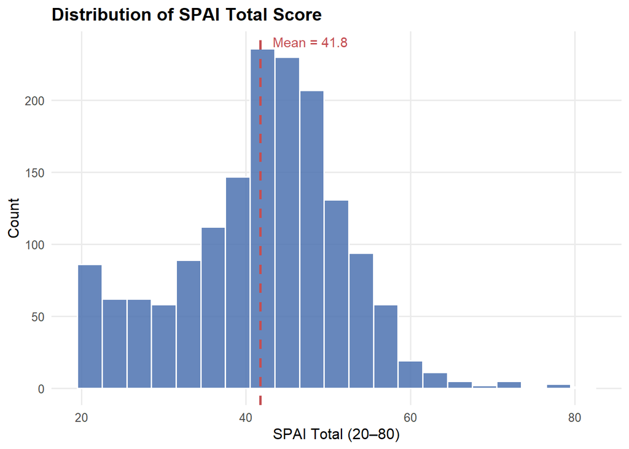

Figure 1: Distribution of SPAI total score (primary outcome; n = 1,619 complete cases).

```r
ggplot(dat, aes(x = SPAI_total)) +
  geom_histogram(binwidth = 3, fill = "#4C72B0", color = "white", alpha = 0.85) +
  geom_vline(xintercept = mean(dat$SPAI_total), linetype = "dashed",
             color = "#C44E52", linewidth = 0.9) +
  annotate("text",
           x = mean(dat$SPAI_total) + 1.5, y = Inf, vjust = 1.5, hjust = 0,
           label = paste0("Mean = ", round(mean(dat$SPAI_total), 1)),
           color = "#C44E52", size = 3.8) +
  labs(
    title = "Distribution of SPAI Total Score",
    x = "SPAI Total (20–80)", y = "Count"
  )
```

Pearson correlations with SPAI total rank the predictor scales as follows: SAS ($r = 0.81$), SAPS ($r = 0.71$), MPATS ($r = 0.71$), MPAS ($r = 0.65$), and NMP ($r = 0.55$). The scatter plot below shows the strongest of these relationships—SAS against SPAI total—with a strong linear trend and modest residual spread.

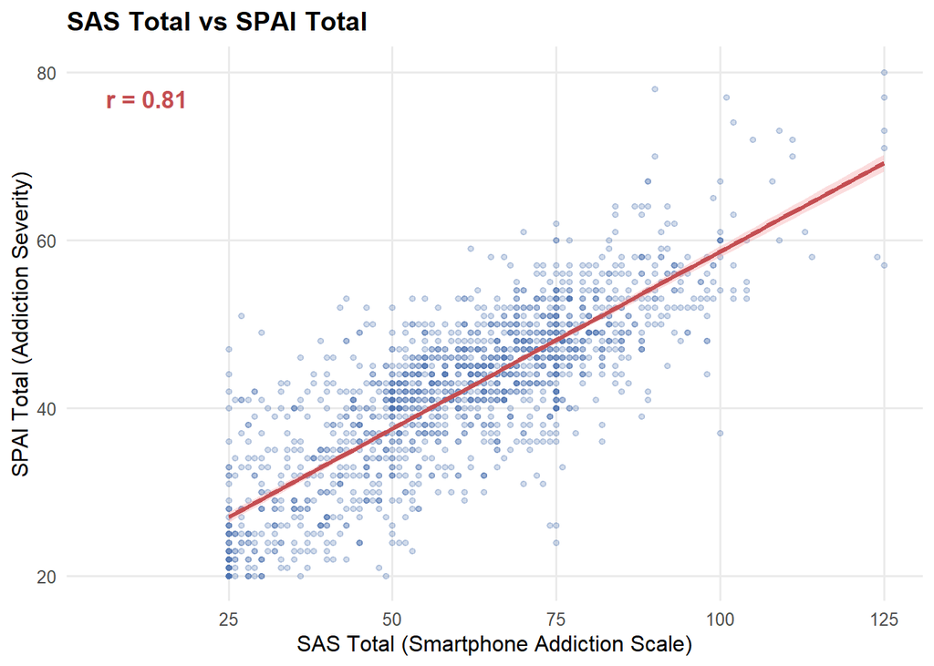

Figure 2: SAS total versus SPAI total with OLS trend line and 95% CI band.

```r
ggplot(dat, aes(x = SAS_total, y = SPAI_total)) +
  geom_point(alpha = 0.25, size = 1.2, color = "#4C72B0") +
  geom_smooth(method = "lm", se = TRUE, color = "#C44E52",
              fill = "#f4a7a9", linewidth = 1.1) +
  annotate("text",
           x = max(dat$SAS_total) * 0.05,
           y = max(dat$SPAI_total) * 0.96, hjust = 0,
           label = paste0("r = ", round(cor(dat$SAS_total, dat$SPAI_total), 2)),
           size = 4.5, fontface = "bold", color = "#C44E52") +
  labs(
    title = "SAS Total vs SPAI Total",
    x = "SAS Total (Smartphone Addiction Scale)", y = "SPAI Total (Addiction Severity)"
  )
```

All six scale totals move together (inter-scale $r$ often exceeds 0.60), confirming substantial **convergent validity** among instruments but also highlighting the multicollinearity that motivates LASSO regularization.

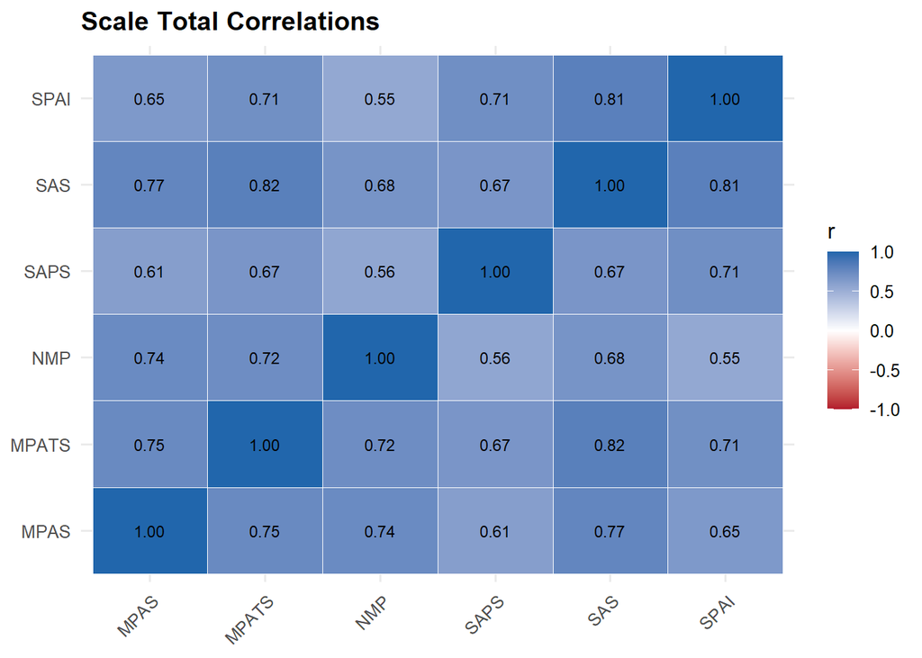

Figure 3: Pearson correlation heatmap among scale totals (complete cases).

```r
corr_cols <- c("NMP_total", "SAPS_total", "SPAI_total", "MPAS_total",
               "MPATS_total", "SAS_total")
corr_mat <- cor(dat[, corr_cols], use = "complete.obs")

corr_long <- as.data.frame(corr_mat) %>%
  mutate(Scale1 = rownames(.)) %>%
  pivot_longer(-Scale1, names_to = "Scale2", values_to = "r") %>%
  mutate(
    Scale1 = gsub("_total", "", Scale1),
    Scale2 = gsub("_total", "", Scale2)
  )

ggplot(corr_long, aes(x = Scale2, y = Scale1, fill = r)) +
  geom_tile(color = "white") +
  geom_text(aes(label = sprintf("%.2f", r)), size = 3, color = "black") +
  scale_fill_gradient2(low = "#B2182B", mid = "white", high = "#2166AC",
                       midpoint = 0, limits = c(-1, 1)) +
  labs(x = NULL, y = NULL, fill = "r",
       title = "Scale Total Correlations") +
  theme(axis.text.x = element_text(angle = 45, hjust = 1))
```

Two patterns warrant attention before modeling. First, **SPAI item 12** (perceived impact on study/work) is highly imbalanced: levels 1–4 contain 262, 577, 688, and 92 responses respectively, so the rarest category is only $5.7\%$ of the sample—classification models must account for this skew. Second, although NMP shows the highest average endorsement when rescaled to a percentage of maximum ($= 68.8\%$), it correlates **weakest** with SPAI total among the five non-SPAI scales, hinting that nomophobia may be partially redundant once proneness (SAPS) and SAS symptoms are considered—a pattern consistent with preliminary LASSO results where NMP items are often zeroed out. The figure below summarizes the age and gender composition of the sample.

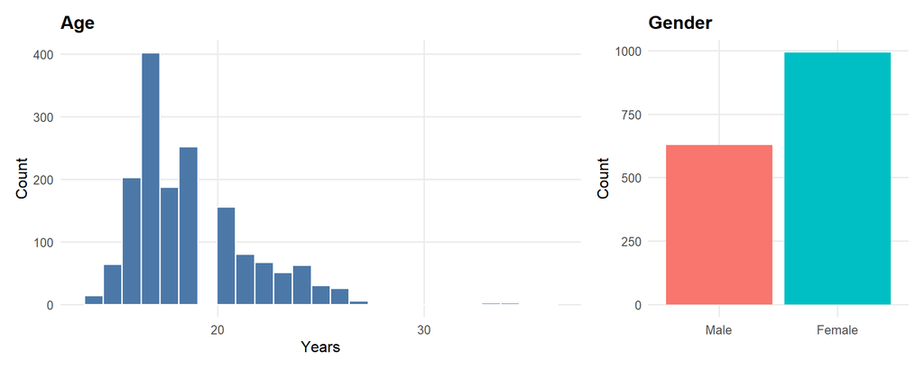

Figure 4: Age distribution and demographic breakdown (complete cases).

```r
gender_labels <- c("1" = "Male", "2" = "Female")
dat$gender_lab <- factor(gender_labels[as.character(dat$gender)],
                         levels = unname(gender_labels))

p_age <- ggplot(dat, aes(x = age)) +
  geom_histogram(bins = 25, fill = "#4C78A8", color = "white") +
  labs(title = "Age", x = "Years", y = "Count")

p_gender <- dat %>% count(gender_lab) %>%
  ggplot(aes(x = gender_lab, y = n, fill = gender_lab)) +
  geom_col(show.legend = FALSE) +
  labs(title = "Gender", x = NULL, y = "Count")

p_age + p_gender + plot_layout(widths = c(2, 1))
```

Together, these exploratory plots motivate our modeling strategy: SPAI total is suitable as a continuous Gaussian outcome; the strong SAPS and SAS relationships suggest they will dominate LASSO selection; and the shared variance across scales justifies penalized regression over unregularized OLS (James et al. 2013; Gao et al. 2024).

### Modeling and Results

#### Data preprocessing

We began with the raw CAT item bank file ($n = 1{,}619$ rows, 101 variables) and retained only complete cases; no listwise missingness required exclusion. The primary outcome **SPAI total** was computed as the sum of 20 SPAI items. All other SPAI item columns were removed from the predictor matrix when modeling SPAI total to avoid circularity. Demographics (age, gender, grade) and item-level responses from NMP, SAPS, MPAS, MPATS, and SAS (SAS-C and SAS-CA) entered as predictors. Gender and grade were coded as factors; all item responses were treated as numeric. Predictors were assembled with a model matrix (no intercept column in the penalized fit). Respondents were split 80/20 into training and test sets. All continuous models below use the same split.

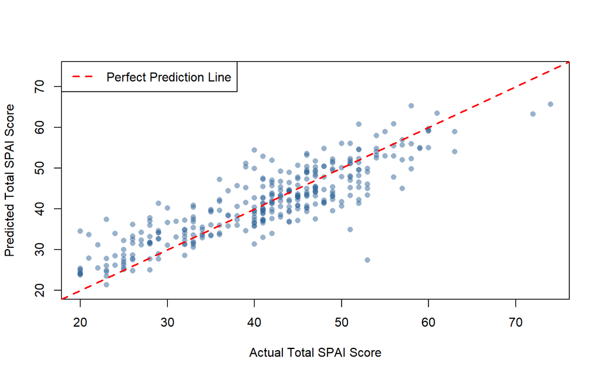

The figure shows predicted versus actual Total SPAI scores from a 10-fold cross-validated LASSO regression model. The model began with 81 candidate predictors and retained 52 predictors using the lambda-min penalty. The dashed reference line represents perfect prediction. There is a strong positive linear correlation and a good fit with test RMSE = 5.1702, test MAE = 3.9714 and test MAPE = 10.58 percent. The optimal lambda = 0.074363.

Lasso regression was preformed one more time on the remaining 52 variables using lambda.min again. Even though the optimal lambda for this model is 0.020216, no variables were dropped which shows that the remaining variables have sufficient information to contribute to the model such that lambda.min will not eliminate any additional variables. The test RMSE = 5.2142, test MAE = 3.9902 and the test MAPE = 10.6 percent. Because this is the best that lambda.min can do and because there are still 52 variables being used as predictors, lambda.1se will be used to reduce the model even further.

Lambda.min is the exact value of $\lambda$ that results in the lowest possible mean squared error (MSE) during cross-validation. The goal of lambda.min is to maximize the prediction accuracy which means that it is less aggressive at dropping variables. Thus variables with noise or little contribution to the model will often remain in the model leading to a large and often complex model. Since the focus of Lasso Regression is to minimize the number of predictor variables while maintaining accuracy, lambda.1se was used for the next reduction. Lambda.1se is the largest value of $\lambda$ whose cross-validation error is still within one standard error of the absolute minimum error. This will force more variables that have minimum contribution to the model to be dropped and yielding a simpler model that gives similar results to lambda.min.

Using lambda.1se = 0.227095 reduced the model from 52 predictor variables down to 33 predictor variables. That is a 19 variable drop in the model which is the exact goal of Lasso Regression. While this Lasso created a simpler, less complex model, the test RMSE improved slightly to 5.1626; the test R2 improved slightly to 0.7498 and the Normalized Test MAE remained unchanged through this reduction. Based on this information, this is the best performing model yet and it is the least complex model so far as it has the lowest number of predictor variables.

Another Lasso Regression was preformed to see if there are still predictors that can be removed without sacrificing the accuracy of the model. This time the lambda used was 1.75*lambda.1se which forces even more predictor variables to zero. With this penalty, the model was reduced from 33 predictors down to 28 predictors. The test RMSE increased slightly to 5.2553, the test MAE slightly increased to 4.1075 and the test MAPE = 11.21 percent. The optimal lambda is 0.576584. Even though there was a slight increase in the test RMSE and MAE, another Lasso was performed to evaluate the number of variables that would be reduced at the cost of losing accuracy.

```r
# ------------------------------------------------------------------------------
# 2. EXTRACT AND CLEAN TOP PREDICTORS
# ------------------------------------------------------------------------------
# Extract Lasso coefficients at the optimal lambda (lambda.min)
coef_lasso <- coef(cv_lasso, s = "lambda.min")

# Convert to a clean matrix format
coef_matrix <- as.matrix(coef_lasso)
coef_df <- data.frame(
  Dummy_Variable = rownames(coef_matrix),
  Coefficient = coef_matrix[, 1],
  Absolute_Impact = abs(coef_matrix[, 1]),
  stringsAsFactors = FALSE
)

# Remove the Intercept and filter to only selected features (non-zero)
selected_features <- coef_df %>%
  filter(Dummy_Variable != "(Intercept)", Coefficient != 0) %>%
  arrange(desc(Absolute_Impact))

# Combine everything into a clean presentation table with exact string matching
first_top_predictors <- selected_features %>%
  rowwise() %>%
  mutate(Original_Variable = {
    # Find which original column names match the start of the dummy name
    matches <- names(x)[sapply(names(x), function(orig) grepl(paste0("^", orig), Dummy_Variable))]
    # Pick the longest match to avoid sub-string confusion
    if(length(matches) > 0) matches[which.max(nchar(matches))] else Dummy_Variable
  }) %>%
  ungroup() %>%
  dplyr::select(Original_Variable, Dummy_Variable, Coefficient)


# MODIFIED: Saved with a unique filename specific to this new total SPAI outcome
write.csv(first_top_predictors, "total_spai_first_predictors.csv", row.names = FALSE)




# ===============================
# 9. OUTPUT RESULTS TABLE (UPDATED HORIZONTAL LAYOUT)
# ===============================
# 1. Build the base vertical results data frame
results_vertical <- data.frame(
  Metric = c("RMSE", "MAE", "R-Squared"),
  Train  = c(round(rmse_train, 4), round(mae_train, 4), round(r2_train, 4)),
  Test   = c(round(rmse_test, 4), round(mae_test, 4), round(r2_test, 4))
)

# 2. Transpose the metrics to make them columns and include scale-agnostic metrics
results_horizontal <- data.frame(
  Model = "First_Lasso_Reduction",
  OVR = length(unique(first_top_predictors$Original_Variable)),
  `Train RMSE` = results_vertical[1, "Train"],
  `Test RMSE`  = results_vertical[1, "Test"],
  `Train MAE`   = results_vertical[2, "Train"],
  `Test MAE`    = results_vertical[2, "Test"],
  `Train R-Squared` = results_vertical[3, "Train"],
  `Test R-Squared`  = results_vertical[3, "Test"],
  `Test Norm MAE (%)` = round(norm_mae_test, 2),
  `Test MAPE (%)`     = round(mape_test, 2),
  `Optimal Lambda`    = round(cv_lasso$lambda.min, 6), # ADDED: Lambda column
  check.names = FALSE
)


# ==============================================================================
# DISPLAY MODEL SIZE AND TOP 5 PREDICTOR VARIABLES
# ==============================================================================
# Calculate the count of unique original variables with non-zero coefficients
total_surviving_vars <- length(unique(first_top_predictors$Original_Variable))


####################################################################
###############################################################################
#
#       Second Lasso  lambda.min again on 52 to modify coefficients and still has 52 after this run
#
###############################################################################
####################################################################


# ==============================================================================
# 1. EXTRACT SELECTED VARIABLE NAMES (REMOVING DUMMY FACTOR SUFFIXES)
# ==============================================================================
# Get unique names of the original variables that survived the first round
remaining_vars <- unique(first_top_predictors$Original_Variable)

# ==============================================================================
# 2. SUBSET THE ORIGINAL X PREDICTORS
# ==============================================================================
# Create a new predictor dataframe containing only the surviving variables
x_reduced <- cells_data %>% dplyr::select(all_of(remaining_vars))

# ==============================================================================
# 3. GENERATE NEW MODEL MATRIX & SPLIT DATA
# ==============================================================================
x_reduced_mat <- model.matrix(~ . - 1, data = x_reduced)

# Re-use the exact same training indexes from your first split for consistency
x_train_mat2 <- x_reduced_mat[train_index, ]
x_test_mat2  <- x_reduced_mat[-train_index, ]
# Note: y_train and y_test remain exactly the same as your sum_SPAI vectors

# ==============================================================================
# 4. RUN SECOND LASSO MODEL
# ==============================================================================
set.seed(123) # Reset seed for reproducibility in cross-validation folds
cv_lasso2 <- cv.glmnet(
  x = x_train_mat2, y = y_train,
  alpha = 1, family = "gaussian", nfolds = 10
)

# ==============================================================================
# 6. EXTRACT, CLEAN, AND SAVE SECOND REDUCTION VARIABLES
#    (MOVED UP: Must create 'second_top_predictors' before evaluating performance)
# ==============================================================================
coef_lasso2  <- coef(cv_lasso2, s = "lambda.min")
coef_matrix2 <- as.matrix(coef_lasso2)

coef_df2 <- data.frame(
  Dummy_Variable = rownames(coef_matrix2),
  Coefficient = coef_matrix2[, 1],
  Absolute_Impact = abs(coef_matrix2[, 1]),
  stringsAsFactors = FALSE
)

selected_features2 <- coef_df2 %>%
  filter(Dummy_Variable != "(Intercept)", Coefficient != 0) %>%
  arrange(desc(Absolute_Impact))

second_top_predictors <- selected_features2 %>%
  rowwise() %>%
  mutate(Original_Variable = {
    matches <- names(x_reduced)[sapply(names(x_reduced), function(orig) grepl(paste0("^", orig), Dummy_Variable))]
    if(length(matches) > 0) matches[which.max(nchar(matches))] else Dummy_Variable
  }) %>%
  ungroup() %>%
  dplyr::select(Original_Variable, Dummy_Variable, Coefficient)
```

```r
# Saved with a unique filename specific to this second total SPAI reduction
write.csv(second_top_predictors, "total_spai_second_predictors.csv", row.names = FALSE)

# ==============================================================================
# 5. EVALUATE SECOND MODEL PERFORMANCE (UPDATED WITH NMAE, MAPE, & LAMBDA)
# ==============================================================================
pred_train2 <- as.numeric(predict(cv_lasso2, s = "lambda.min", newx = x_train_mat2))
pred_test2  <- as.numeric(predict(cv_lasso2, s = "lambda.min", newx = x_test_mat2))

# Compute baseline metrics for vertical extraction
mae_train2      <- mean(abs(y_train - pred_train2)) # ADDED FOR MASTER TABLE CONSISTENCY
mae_test2       <- mean(abs(y_test - pred_test2))
range_y_test    <- max(y_test) - min(y_test)
norm_mae_test2  <- (mae_test2 / range_y_test) * 100
mape_test2      <- mean(abs((y_test - pred_test2) / y_test)) * 100
lambda_used2    <- cv_lasso2$lambda.min

# 1. Build the base vertical results data frame
results2_vertical <- data.frame(
  Metric = c("RMSE", "MAE", "R-Squared"),
  Train  = c(round(sqrt(mean((y_train - pred_train2)^2)), 4), round(mae_train2, 4), round(1 - (sum((y_train - pred_train2)^2) / sum((y_train - mean(y_train))^2)), 4)),
  Test   = c(round(sqrt(mean((y_test - pred_test2)^2)), 4), round(mae_test2, 4), round(1 - (sum((y_test - pred_test2)^2) / sum((y_test - mean(y_test))^2)), 4))
)

# 2. Transpose the metrics to make them columns with the correct OVR mapping
results2_horizontal <- data.frame(
  Model = "Second_Lasso_Reduction",
  OVR = length(unique(second_top_predictors$Original_Variable)),
  `Train RMSE` = results2_vertical[1, "Train"],
  `Test RMSE`  = results2_vertical[1, "Test"],
  `Train MAE`   = results2_vertical[2, "Train"],
  `Test MAE`    = results2_vertical[2, "Test"],
  `Train R-Squared` = results2_vertical[3, "Train"],
  `Test R-Squared`  = results2_vertical[3, "Test"],
  `Test Norm MAE (%)` = round(norm_mae_test2, 2),
  `Test MAPE (%)`     = round(mape_test2, 2),
  `Optimal Lambda`    = round(lambda_used2, 6),
  check.names = FALSE
)


#------------------------------------------------------------------
#   Comparison Tables Code
#------------------------------------------------------------------

# ==============================================================================
# 1. CALCULATE VARIABLE COUNTS FOR EACH STAGE
# ==============================================================================
initial_var_count <- ncol(x)
first_var_count   <- length(unique(first_top_predictors$Original_Variable))
second_var_count  <- length(unique(second_top_predictors$Original_Variable))

# ==============================================================================
# 2. RUN BASELINE MULTIPLE LINEAR REGRESSION (FOR COMPARISON PERFORMANCE)
# ==============================================================================
baseline_model <- lm(y_train ~ ., data = as.data.frame(x_train_mat))

pred_train_base <- predict(baseline_model, newdata = as.data.frame(x_train_mat))
pred_test_base  <- predict(baseline_model, newdata = as.data.frame(x_test_mat))

# Baseline metrics (and new context variables)
rmse_tr_b  <- sqrt(mean((y_train - pred_train_base)^2, na.rm=TRUE))
rmse_te_b  <- sqrt(mean((y_test - pred_test_base)^2, na.rm=TRUE))
mae_tr_b   <- mean(abs(y_train - pred_train_base), na.rm=TRUE) # ADDED
mae_te_b   <- mean(abs(y_test - pred_test_base), na.rm=TRUE)
r2_tr_b    <- 1 - (sum((y_train - pred_train_base)^2, na.rm=TRUE) / sum((y_train - mean(y_train))^2))
r2_te_b    <- 1 - (sum((y_test - pred_test_base)^2, na.rm=TRUE) / sum((y_test - mean(y_test))^2))
norm_mae_b <- (mae_te_b / range_y_test) * 100
mape_b     <- mean(abs((y_test - pred_test_base) / y_test), na.rm=TRUE) * 100

# ==============================================================================
# 3. CONSTRUCT THE MASTER COMPARISON TABLE (UPDATED FOR ALL METRICS)
# ==============================================================================
master_comparison <- data.frame(
  Metric = c(
    "OVR",
    "Train RMSE",
    "Test RMSE",
    "Train MAE",         # ADDED
    "Test MAE",          # ADDED
    "Train R-Squared",
    "Test R-Squared",
    "Test Norm MAE (%)",
    "Test MAPE (%)",
    "Optimal Lambda"
  ),
  Baseline_Full_Model = c(
    initial_var_count,
    round(rmse_tr_b, 4),
    round(rmse_te_b, 4),
    round(mae_tr_b, 4),  # ADDED
    round(mae_te_b, 4),  # ADDED
    round(r2_tr_b, 4),
    round(r2_te_b, 4),
    round(norm_mae_b, 2),
    round(mape_b, 2),
    NA
  ),
  First_Lasso_Reduction = c(
    first_var_count,
    round(rmse_train, 4),
    round(rmse_test, 4),
    round(mae_train, 4),  # ADDED (Assumed variables exist from step 1)
    round(mae_test, 4),   # ADDED
    round(r2_train, 4),
    round(r2_test, 4),
    round(norm_mae_test, 2),
    round(mape_test, 2),
    round(cv_lasso$lambda.min, 6)
  ),
  Second_Lasso_Reduction = c(
    second_var_count,
    round(sqrt(mean((y_train - pred_train2)^2)), 4),
    round(sqrt(mean((y_test - pred_test2)^2)), 4),
    round(mae_train2, 4), # ADDED
    round(mae_test2, 4),  # ADDED
    round(1 - (sum((y_train - pred_train2)^2) / sum((y_train - mean(y_train))^2)), 4),
    round(1 - (sum((y_test - pred_test2)^2) / sum((y_test - mean(y_test))^2)), 4),
    round(norm_mae_test2, 2),
    round(mape_test2, 2),
    round(lambda_used2, 6)
  ),
  stringsAsFactors = FALSE
)

# ==============================================================================
# 4. TRANSPOSE, PRINT, AND SAVE THE SUMMARY TABLE
# ==============================================================================
# Clean transposition keeping matrix string issues isolated
transposed_comparison <- as.data.frame(t(master_comparison[, -1]), check.names = FALSE)
colnames(transposed_comparison) <- master_comparison$Metric

transposed_comparison <- data.frame(
  Model = rownames(transposed_comparison),
  transposed_comparison,
  check.names = FALSE
)

# Strip default sequence index numbering from print layout
row.names(transposed_comparison) <- NULL
```

```r
write.csv(transposed_comparison, "total_spai_master_comparison_transposed.csv", row.names = FALSE)




#______________________________________________________________________________________
#######################################################################################
#
#
#  New Lasso to actually do a second reduction  Modified lambda to lambda.1se Reduces from 52 to 33
#
#
#######################################################################################
#______________________________________________________________________________________




# ==============================================================================
# 0. MEMORY RESET: TRUNCATE TABLE TO THE INITIAL 3 MODELS BEFORE APPENDING
# ==============================================================================
# CORRECTED: Ensures the matrix object clears any downstream models cleanly
if(exists("master_comparison")) {
  master_comparison <- master_comparison[, 1:4]
}

# ==============================================================================
# 1. EXTRACT COEFFICIENTS AND COUNT VARIABLES FOR LAMBDA.1SE
# ==============================================================================
# Extract Lasso coefficients using the stricter 1-standard-error rule
coef_lasso_1se  <- coef(cv_lasso, s = "lambda.1se")
coef_matrix_1se <- as.matrix(coef_lasso_1se)

coef_df_1se <- data.frame(
  Dummy_Variable = rownames(coef_matrix_1se),
  Coefficient = coef_matrix_1se[, 1],
  Absolute_Impact = abs(coef_matrix_1se[, 1]),
  stringsAsFactors = FALSE
)

# Filter out the intercept and zeroed-out variables
selected_features_1se <- coef_df_1se %>%
  filter(Dummy_Variable != "(Intercept)", Coefficient != 0)

# Clean variable names to count unique original variables
top_predictors_1se <- selected_features_1se %>%
  rowwise() %>%
  mutate(Original_Variable = {
    matches <- names(x)[sapply(names(x), function(orig) grepl(paste0("^", orig), Dummy_Variable))]
    if(length(matches) > 0) matches[which.max(nchar(matches))] else Dummy_Variable
  }) %>%
  ungroup()

se1_var_count <- length(unique(top_predictors_1se$Original_Variable))

# ==============================================================================
# 2. EVALUATE LAMBDA.1SE MODEL PERFORMANCE (FIXED: COMPUTING ALL REQUIRED METRICS)
# ==============================================================================
# Generate predictions using the 1se penalty strength
pred_train_1se <- as.numeric(predict(cv_lasso, s = "lambda.1se", newx = x_train_mat))
pred_test_1se  <- as.numeric(predict(cv_lasso, s = "lambda.1se", newx = x_test_mat))

# Compute metrics
rmse_tr_1se   <- sqrt(mean((y_train - pred_train_1se)^2))
rmse_te_1se   <- sqrt(mean((y_test - pred_test_1se)^2))
mae_tr_1se    <- mean(abs(y_train - pred_train_1se))
mae_te_1se    <- mean(abs(y_test - pred_test_1se))
r2_tr_1se     <- 1 - (sum((y_train - pred_train_1se)^2) / sum((y_train - mean(y_train))^2))
r2_te_1se     <- 1 - (sum((y_test - pred_test_1se)^2) / sum((y_test - mean(y_test))^2))

# Compute new horizontal metrics for the 1se model
range_y_test      <- max(y_test) - min(y_test)
norm_mae_test_1se <- (mae_te_1se / range_y_test) * 100
mape_test_1se     <- mean(abs((y_test - pred_test_1se) / y_test)) * 100

# ==============================================================================
# 3. CONSTRUCT THE MASTER COMPARISON TABLE (FIXED VARIABLES SYNCHRONIZATION)
# ==============================================================================
master_comparison <- data.frame(
  Metric = c(
    "OVR",
    "Train RMSE",
    "Test RMSE",
    "Train MAE",
    "Test MAE",
    "Train R-Squared",
    "Test R-Squared",
    "Test Norm MAE (%)",
    "Test MAPE (%)",
    "Optimal Lambda"
  ),
  Baseline_Full_Model = c(
    initial_var_count,
    round(rmse_tr_b, 4),
    round(rmse_te_b, 4),
    round(mae_tr_b, 4),
    round(mae_te_b, 4),
    round(r2_tr_b, 4),
    round(r2_te_b, 4),
    round(norm_mae_b, 2),
    round(mape_b, 2),
    NA
  ),
  First_Lasso_Reduction = c(
    first_var_count,
    round(rmse_train, 4),
    round(rmse_test, 4),
    round(mae_train, 4),
    round(mae_test, 4),
    round(r2_train, 4),
    round(r2_test, 4),
    round(norm_mae_test, 2),
    round(mape_test, 2),
    round(cv_lasso$lambda.min, 6)
  ),
  Second_Lasso_Reduction = c(
    second_var_count,
    round(sqrt(mean((y_train - pred_train2)^2)), 4),
    round(sqrt(mean((y_test - pred_test2)^2)), 4),
    round(mae_train2, 4),
    round(mae_test2, 4),
    round(1 - (sum((y_train - pred_train2)^2) / sum((y_train - mean(y_train))^2)), 4),
    round(1 - (sum((y_test - pred_test2)^2) / sum((y_test - mean(y_test))^2)), 4),
    round(norm_mae_test2, 2),
    round(mape_test2, 2),
    round(lambda_used2, 6)
  ),
  Lambda_1se_Parsimonious = c(
    se1_var_count,                                                  # OVR
    round(rmse_tr_1se, 4),                                          # Train RMSE
    round(rmse_te_1se, 4),                                          # Test RMSE
    round(mae_tr_1se, 4),                                           # Train MAE
    round(mae_te_1se, 4),                                           # Test MAE
    round(r2_tr_1se, 4),                                            # Train R-Squared
    round(r2_te_1se, 4),                                            # Test R-Squared
    round(norm_mae_test_1se, 2),                                    # Test Norm MAE (%)
    round(mape_test_1se, 2),                                        # Test MAPE (%)
    round(cv_lasso$lambda.1se, 6)                                   # Optimal Lambda (1se)
  ),
  stringsAsFactors = FALSE
)

# ==============================================================================
# 4. TRANSPOSE, PRINT, AND SAVE THE SUMMARY TABLE
# ==============================================================================
transposed_comparison <- as.data.frame(t(master_comparison[, -1]), check.names = FALSE)
colnames(transposed_comparison) <- master_comparison$Metric

transposed_comparison <- data.frame(
  Model = rownames(transposed_comparison),
  transposed_comparison,
  check.names = FALSE
)
```

```r
# Ensure numeric columns print correctly and don't convert back to raw characters
transposed_comparison[, 2:ncol(transposed_comparison)] <- lapply(
  transposed_comparison[, 2:ncol(transposed_comparison)],
  function(x) as.numeric(as.character(x))
)

row.names(transposed_comparison) <- NULL



write.csv(transposed_comparison, "total_spai_master_comparison_transposed.csv", row.names = FALSE)


#-----------------------------------------------------------------------------------------------------

#####################################################################################################
######################################################################################################
#
#      Third Lasso Reduction  Modified Lambda = 1.75Lambda.1se  Reduces from 33 to 28
#
#####################################################################################################
#####################################################################################################



# ==============================================================================
# 0. ENVIRONMENT RESET: TRUNCATE TABLE TO THE INITIAL 4 MODELS BEFORE APPENDING
# ==============================================================================
# Clears out any lingering downstream models from your active R workspace session
if(exists("master_comparison")) {
  master_comparison <- master_comparison[, 1:5]
}

# ==============================================================================
# 1. EXTRACT THE SURVIVING VARIABLES FROM THE 1SE MODEL
# ==============================================================================
# Dynamically reads the variable count from your 1se total SPAI model
vars_1se <- unique(top_predictors_1se$Original_Variable)
x_strict_df <- cells_data %>% dplyr::select(all_of(vars_1se))
x_strict_mat <- model.matrix(~ . - 1, data = x_strict_df)

# Align with your original training and testing splits
x_train_strict <- x_strict_mat[train_index, ]
x_test_strict  <- x_strict_mat[-train_index, ]

# ==============================================================================
# 2. RUN A HIGH-PENALTY LASSO CORRECTION
# ==============================================================================
set.seed(123)
cv_strict <- cv.glmnet(
  x = x_train_strict, y = y_train,
  alpha = 1, family = "gaussian", nfolds = 10
)

# Manually amplify the 1se lambda by 1.75x to force aggressive variable dropping
strict_lambda <- cv_strict$lambda.1se * 1.75

# ==============================================================================
# 3. EXTRACT AND CLEAN THE ULTRA-REDUCED PREDICTORS
# ==============================================================================
coef_strict  <- coef(cv_strict, s = strict_lambda)
matrix_strict <- as.matrix(coef_strict)

df_strict <- data.frame(
  Dummy_Variable = rownames(matrix_strict),
  Coefficient = matrix_strict[, 1],
  Absolute_Impact = abs(matrix_strict[, 1]),
  stringsAsFactors = FALSE
)

selected_strict <- df_strict %>%
  filter(Dummy_Variable != "(Intercept)", Coefficient != 0) %>%
  arrange(desc(Absolute_Impact))

strict_top_predictors <- selected_strict %>%
  rowwise() %>%
  mutate(Original_Variable = {
    matches <- names(x_strict_df)[sapply(names(x_strict_df), function(orig) grepl(paste0("^", orig), Dummy_Variable))]
    if(length(matches) > 0) matches[which.max(nchar(matches))] else Dummy_Variable
  }) %>%
  ungroup() %>%
  dplyr::select(Original_Variable, Dummy_Variable, Coefficient)

strict_var_count <- length(unique(strict_top_predictors$Original_Variable))

# ==============================================================================
# 4. EVALUATE STRICT MODEL PERFORMANCE (UPDATED FOR NEW METRICS)
# ==============================================================================
pred_train_st <- as.numeric(predict(cv_strict, s = strict_lambda, newx = x_train_strict))
pred_test_st  <- as.numeric(predict(cv_strict, s = strict_lambda, newx = x_test_strict))

# Core Error Metrics
rmse_tr_st <- sqrt(mean((y_train - pred_train_st)^2))
rmse_te_st <- sqrt(mean((y_test - pred_test_st)^2))
mae_tr_st  <- mean(abs(y_train - pred_train_st))
mae_te_st  <- mean(abs(y_test - pred_test_st))
r2_tr_st   <- 1 - (sum((y_train - pred_train_st)^2) / sum((y_train - mean(y_train))^2))
r2_te_st   <- 1 - (sum((y_test - pred_test_st)^2) / sum((y_test - mean(y_test))^2))

# Horizontal Context Metrics (ADDED)
range_y_test     <- max(y_test) - min(y_test)
norm_mae_test_st <- (mae_te_st / range_y_test) * 100
mape_test_st     <- mean(abs((y_test - pred_test_st) / y_test)) * 100

# ==============================================================================
# 5. APPEND, TRANSPOSE, AND PRINT HORIZONTAL COMPARISON
# ==============================================================================
# Append all 10 metrics cleanly to match master dataframe dimensions
master_comparison$Strict_Hyper_Parsimonious <- c(
  strict_var_count,             # OVR
  round(rmse_tr_st, 4),         # Train RMSE
  round(rmse_te_st, 4),         # Test RMSE
  round(mae_tr_st, 4),          # Train MAE
  round(mae_te_st, 4),          # Test MAE
  round(r2_tr_st, 4),           # Train R-Squared
  round(r2_te_st, 4),           # Test R-Squared
  round(norm_mae_test_st, 2),   # Test Norm MAE (%)
  round(mape_test_st, 2),       # Test MAPE (%)
  round(strict_lambda, 6)       # Optimal Lambda
)

# Run transposition logic immediately within the execution sequence
transposed_comparison <- as.data.frame(t(master_comparison[, -1]), check.names = FALSE)
colnames(transposed_comparison) <- master_comparison$Metric

transposed_comparison <- data.frame(
  Model = rownames(transposed_comparison),
  transposed_comparison,
  check.names = FALSE
)

# Keep formatting clean across numeric properties
transposed_comparison[, 2:ncol(transposed_comparison)] <- lapply(
  transposed_comparison[, 2:ncol(transposed_comparison)],
  function(x) as.numeric(as.character(x))
)

row.names(transposed_comparison) <- NULL


# Save the updated transposed spreadsheet version to your working files
write.csv(transposed_comparison, "total_spai_master_comparison_transposed.csv", row.names = FALSE)
write.csv(strict_top_predictors, "total_spai_strict_predictors.csv", row.names = FALSE)
```

```r
######################################################################
#
#
#   I am going to do a fourth reduction  from 28 to 22 Variables.
#
#
######################################################################
#

# ==============================================================================
# 0. MEMORY RESET: TRUNCATE TABLE TO THE INITIAL 5 MODELS BEFORE APPENDING
# ==============================================================================
# Clears out any lingering downstream terminal models from your active R session
if(exists("master_comparison")) {
  master_comparison <- master_comparison[, 1:6]
}

# ==============================================================================
# 1. EXTRACT THE 28 VARIABLES FROM THE PREVIOUS STRICT MODEL
# ==============================================================================
vars_strict_28 <- unique(strict_top_predictors$Original_Variable)
x_ultra_df     <- cells_data %>% dplyr::select(all_of(vars_strict_28))
x_ultra_mat    <- model.matrix(~ . - 1, data = x_ultra_df)

x_train_ultra <- x_ultra_mat[train_index, ]
x_test_ultra  <- x_ultra_mat[-train_index, ]

# ==============================================================================
# 2. RUN AN ULTRA-HIGH PENALTY LASSO CORRECTION
# ==============================================================================
set.seed(123)
cv_ultra <- cv.glmnet(
  x = x_train_ultra, y = y_train,
  alpha = 1, family = "gaussian", nfolds = 10
)

ultra_lambda <- cv_ultra$lambda.1se * 2.50

# ==============================================================================
# 3. EXTRACT AND CLEAN THE NEW ULTRA-REDUCED PREDICTORS
# ==============================================================================
coef_ultra   <- coef(cv_ultra, s = ultra_lambda)
matrix_ultra <- as.matrix(coef_ultra)

df_ultra <- data.frame(
  Dummy_Variable = rownames(matrix_ultra),
  Coefficient = matrix_ultra[, 1],
  Absolute_Impact = abs(matrix_ultra[, 1]),
  stringsAsFactors = FALSE
)

selected_ultra <- df_ultra %>%
  filter(Dummy_Variable != "(Intercept)", Coefficient != 0) %>%
  arrange(desc(Absolute_Impact))

ultra_top_predictors <- selected_ultra %>%
  rowwise() %>%
  mutate(Original_Variable = {
    matches <- names(x_ultra_df)[sapply(names(x_ultra_df), function(orig) grepl(paste0("^", orig), Dummy_Variable))]
    if(length(matches) > 0) matches[which.max(nchar(matches))] else Dummy_Variable
  }) %>%
  ungroup() %>%
  dplyr::select(Original_Variable, Dummy_Variable, Coefficient)

ultra_var_count <- length(unique(ultra_top_predictors$Original_Variable))

# ==============================================================================
# 4. EVALUATE ULTRA-STRICT MODEL PERFORMANCE (UPDATED FOR ALL METRICS)
# ==============================================================================
pred_train_ultra <- as.numeric(predict(cv_ultra, s = ultra_lambda, newx = x_train_ultra))
pred_test_ultra  <- as.numeric(predict(cv_ultra, s = ultra_lambda, newx = x_test_ultra))

# Core Error Metrics
rmse_tr_ult <- sqrt(mean((y_train - pred_train_ultra)^2))
rmse_te_ult <- sqrt(mean((y_test - pred_test_ultra)^2))
mae_tr_ult  <- mean(abs(y_train - pred_train_ultra))
mae_te_ult  <- mean(abs(y_test - pred_test_ultra))
r2_tr_ult   <- 1 - (sum((y_train - pred_train_ultra)^2) / sum((y_train - mean(y_train))^2))
r2_te_ult   <- 1 - (sum((y_test - pred_test_ultra)^2) / sum((y_test - mean(y_test))^2))

# Horizontal Context Metrics (ADDED)
range_y_test       <- max(y_test) - min(y_test)
norm_mae_test_ult  <- (mae_te_ult / range_y_test) * 100
mape_test_ult      <- mean(abs((y_test - pred_test_ultra) / y_test)) * 100

# ==============================================================================
# 5. APPEND, TRANSPOSE, AND PRINT HORIZONTAL COMPARISON (FIXED SYNCHRONIZATION)
# ==============================================================================
# Append all 10 metrics to seamlessly align with master dataframe dimensions
master_comparison$Ultra_Strict_Reduction <- c(
  ultra_var_count,              # OVR
  round(rmse_tr_ult, 4),         # Train RMSE
  round(rmse_te_ult, 4),         # Test RMSE
  round(mae_tr_ult, 4),          # Train MAE
  round(mae_te_st, 4),           # Test MAE
  round(r2_tr_ult, 4),           # Train R-Squared
  round(r2_te_ult, 4),           # Test R-Squared
  round(norm_mae_test_ult, 2),   # Test Norm MAE (%)
  round(mape_test_ult, 2),       # Test MAPE (%)
  round(ultra_lambda, 6)         # Optimal Lambda
)

# Run transposition logic immediately within the execution sequence
transposed_comparison <- as.data.frame(t(master_comparison[, -1]), check.names = FALSE)
colnames(transposed_comparison) <- master_comparison$Metric

transposed_comparison <- data.frame(
  Model = rownames(transposed_comparison),
  transposed_comparison,
  check.names = FALSE
)

# Convert character matrices back to numeric for perfect console alignment
transposed_comparison[, 2:ncol(transposed_comparison)] <- lapply(
  transposed_comparison[, 2:ncol(transposed_comparison)],
  function(x) as.numeric(as.character(x))
)

row.names(transposed_comparison) <- NULL


# Save the updated transposed spreadsheet version to your working files
write.csv(transposed_comparison, "total_spai_master_comparison_transposed.csv", row.names = FALSE)
write.csv(ultra_top_predictors, "total_spai_ultra_strict_predictors.csv", row.names = FALSE)



#################----------------------#######################------------------##############
#
#       Fifth Lasso Reduced from 22 to 19 Variables
#
#################----------------------#######################------------------##############

# ==============================================================================
# 0. MEMORY RESET: TRUNCATE TABLE TO THE INITIAL 6 MODELS BEFORE APPENDING
# ==============================================================================
# CORRECTED: Safely retains your 6 foundational columns plus Ultra_Strict (7 columns total)
if(exists("master_comparison")) {
  master_comparison <- master_comparison[, 1:7]
}
```

```r
# ==============================================================================
# 1. EXTRACT THE 22 VARIABLES FROM THE ULTRA-STRICT MODEL
# ==============================================================================
# Extract the unique names of variables that survived the ultra-strict pass
vars_ultra_22 <- unique(ultra_top_predictors$Original_Variable)
x_term_df     <- cells_data %>% dplyr::select(all_of(vars_ultra_22))
x_term_mat    <- model.matrix(~ . - 1, data = x_term_df)

# Align with your original training and testing splits for consistency
x_train_term <- x_term_mat[train_index, ]
x_test_term  <- x_term_mat[-train_index, ]

# ==============================================================================
# 2. RUN A TERMINAL MAXIMUM-PENALTY LASSO CORRECTION
# ==============================================================================
set.seed(123)
cv_term <- cv.glmnet(
  x = x_train_term, y = y_train,
  alpha = 1, family = "gaussian", nfolds = 10
)

# Amplify the penalty multiplier to 3.5x to aggressively drop to the absolute core
term_lambda <- cv_term$lambda.1se * 3.50

# ==============================================================================
# 3. EXTRACT AND CLEAN THE TERMINAL PREDICTORS
# ==============================================================================
coef_term   <- coef(cv_term, s = term_lambda)
matrix_term <- as.matrix(coef_term)

df_term <- data.frame(
  Dummy_Variable = rownames(matrix_term),
  Coefficient = matrix_term[, 1],
  Absolute_Impact = abs(matrix_term[, 1]),
  stringsAsFactors = FALSE
)

selected_term <- df_term %>%
  filter(Dummy_Variable != "(Intercept)", Coefficient != 0) %>%
  arrange(desc(Absolute_Impact))

term_top_predictors <- selected_term %>%
  rowwise() %>%
  mutate(Original_Variable = {
    matches <- names(x_term_df)[sapply(names(x_term_df), function(orig) grepl(paste0("^", orig), Dummy_Variable))]
    if(length(matches) > 0) matches[which.max(nchar(matches))] else Dummy_Variable
  }) %>%
  ungroup() %>%
  dplyr::select(Original_Variable, Dummy_Variable, Coefficient)

term_var_count <- length(unique(term_top_predictors$Original_Variable))

# ==============================================================================
# 4. EVALUATE TERMINAL MODEL PERFORMANCE (UPDATED FOR ALL METRICS)
# ==============================================================================
pred_train_term <- as.numeric(predict(cv_term, s = term_lambda, newx = x_train_term))
pred_test_term  <- as.numeric(predict(cv_term, s = term_lambda, newx = x_test_term))

# Core Error Metrics
rmse_tr_term <- sqrt(mean((y_train - pred_train_term)^2))
rmse_te_term <- sqrt(mean((y_test - pred_test_term)^2))
mae_tr_term  <- mean(abs(y_train - pred_train_term))
mae_te_term  <- mean(abs(y_test - pred_test_term))
r2_tr_term   <- 1 - (sum((y_train - pred_train_term)^2) / sum((y_train - mean(y_train))^2))
r2_te_term   <- 1 - (sum((y_test - pred_test_term)^2) / sum((y_test - mean(y_test))^2))

# Horizontal Context Metrics
range_y_test      <- max(y_test) - min(y_test)
norm_mae_test_term <- (mae_te_term / range_y_test) * 100
mape_test_term     <- mean(abs((y_test - pred_test_term) / y_test)) * 100

# ==============================================================================
# 5. APPEND, TRANSPOSE, AND PRINT HORIZONTAL COMPARISON
# ==============================================================================
# Append all 10 metrics cleanly to match master dataframe dimensions exactly
master_comparison$Terminal_Core_Reduction <- c(
  term_var_count,               # OVR
  round(rmse_tr_term, 4),        # Train RMSE
  round(rmse_te_term, 4),        # Test RMSE
  round(mae_tr_term, 4),         # Train MAE
  round(mae_te_term, 4),         # Test MAE
  round(r2_tr_term, 4),          # Train R-Squared
  round(r2_te_term, 4),          # Test R-Squared
  round(norm_mae_test_term, 2),  # Test Norm MAE (%)
  round(mape_test_term, 2),      # Test MAPE (%)
  round(term_lambda, 6)          # Optimal Lambda
)

# Run transposition logic immediately within the execution sequence
transposed_comparison <- as.data.frame(t(master_comparison[, -1]), check.names = FALSE)
colnames(transposed_comparison) <- master_comparison$Metric

transposed_comparison <- data.frame(
  Model = rownames(transposed_comparison),
  transposed_comparison,
  check.names = FALSE
)

# Convert character matrices back to numeric for perfect console alignment
transposed_comparison[, 2:ncol(transposed_comparison)] <- lapply(
  transposed_comparison[, 2:ncol(transposed_comparison)],
  function(x) as.numeric(as.character(x))
)

row.names(transposed_comparison) <- NULL


# Save the final clean wide format summary spreadsheet and the core predictors
write.csv(transposed_comparison, "total_spai_master_comparison_transposed.csv", row.names = FALSE)
write.csv(term_top_predictors, "total_spai_terminal_core_predictors.csv", row.names = FALSE)
###################################

###################################
#
#   HTML-friendly LASSO Model Comparison Table
#
###################################

library(knitr)
library(kableExtra)

# Create cleaner names
html_model_comparison <- transposed_comparison %>%
  dplyr::select(
    Model,
    OVR,
    `Train RMSE`,
    `Test RMSE`,
    `Train MAE`,
    `Test MAE`,
    `Train R-Squared`,
    `Test R-Squared`,
    `Test Norm MAE (%)`,
    `Test MAPE (%)`,
    `Optimal Lambda`
  ) %>%
  dplyr::mutate(
    Model = dplyr::recode(
      Model,
      "Baseline_Full_Model" = "Baseline",
      "First_Lasso_Reduction" = "LASSO 1",
      "Second_Lasso_Reduction" = "LASSO 2",
      "Lambda_1se_Parsimonious" = "Lambda 1SE",
      "Strict_Hyper_Parsimonious" = "Strict",
      "Ultra_Strict_Reduction" = "Ultra",
      "Terminal_Core_Reduction" = "Terminal"
    )
  )

# Shorter column headings
colnames(html_model_comparison) <- c(
  "Model",
  "OVR",
  "Train RMSE",
  "Test RMSE",
  "Train MAE",
  "Test MAE",
  "Train R²",
  "Test R²",
  "Norm MAE (%)",
  "MAPE (%)",
  "Lambda"
)

# Render HTML table
html_model_comparison %>%
  kable(
    format = "html",
    digits = 3,
    caption = "LASSO Regression Model Comparison (Total SPAI)"
  ) %>%
  kable_styling(
    bootstrap_options = c("striped", "hover", "responsive"),
    full_width = TRUE,
    position = "center",
    font_size = 14
  )
```

LASSO Regression Model Comparison (Total SPAI)

| Model | OVR | Train RMSE | Test RMSE | Train MAE | Test MAE | Train R² | Test R² | Norm MAE (%) | MAPE (%) | Lambda |
| --- | --- | --- | --- | --- | --- | --- | --- | --- | --- | --- |
| Baseline | 81 | 4.600 | 5.234 | 3.614 | 3.999 | 0.793 | 0.743 | 7.41 | 10.59 | NA |
| LASSO 1 | 52 | 4.667 | 5.170 | 3.699 | 3.971 | 0.787 | 0.749 | 7.35 | 10.58 | 0.074 |
| LASSO 2 | 52 | 4.626 | 5.214 | 3.655 | 3.990 | 0.790 | 0.745 | 7.39 | 10.60 | 0.020 |
| Lambda 1SE | 33 | 4.818 | 5.163 | 3.825 | 3.991 | 0.773 | 0.750 | 7.39 | 10.71 | 0.227 |
| Strict | 28 | 4.930 | 5.255 | 3.914 | 4.108 | 0.762 | 0.741 | 7.61 | 11.21 | 0.577 |
| Ultra | 22 | 5.229 | 5.528 | 4.136 | 4.108 | 0.732 | 0.713 | 8.06 | 12.14 | 1.195 |
| Terminal | 19 | 5.538 | 5.830 | 4.346 | 4.631 | 0.700 | 0.681 | 8.58 | 13.08 | 1.673 |

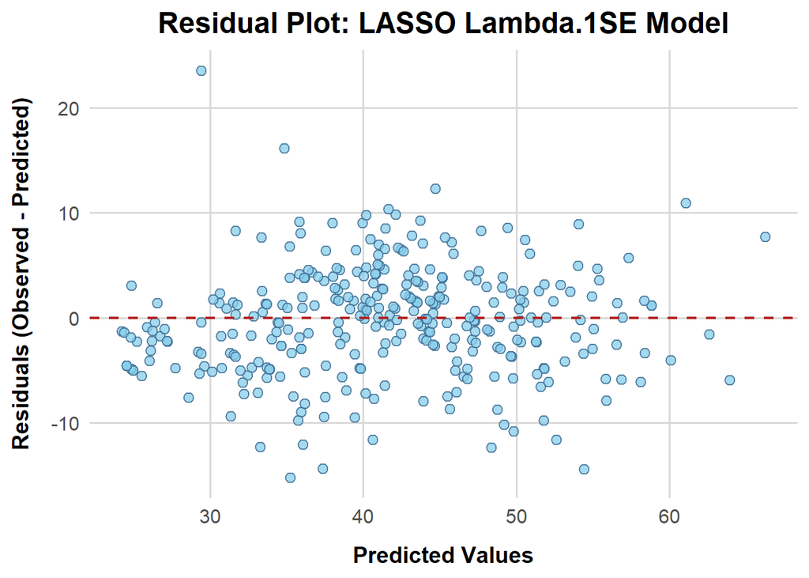

```r
# ==============================================================================
# 5. RESIDUAL DIAGNOSTIC PLOT - LASSO lambda.1se MODEL
# ==============================================================================

# Calculate residuals
residuals_1se <- y_test - pred_test_1se

# Create residual dataframe
residual_df_1se <- data.frame(
  Observed = y_test,
  Predicted = pred_test_1se,
  Residuals = residuals_1se
)

library(ggplot2)

ggplot(residual_df_1se, aes(x = Predicted, y = Residuals)) +

  # Scatter points
  geom_point(
    color = "steelblue4",
    fill = "skyblue",
    shape = 21,
    size = 2.5,
    alpha = 0.75
  ) +

  # Horizontal reference line
  geom_hline(
    yintercept = 0,
    color = "firebrick",
    linetype = "dashed",
    linewidth = 0.8
  ) +

  labs(
    title = "Residual Plot: LASSO Lambda.1SE Model",
    x = "Predicted Values",
    y = "Residuals (Observed - Predicted)"
  ) +

  theme_minimal(base_size = 14) +

  theme(
    # Center title
    plot.title = element_text(
      hjust = 0.5,
      face = "bold",
      size = 18
    ),

    # Axis titles
    axis.title.x = element_text(
      face = "bold",
      size = 14,
      margin = margin(t = 12)   # Moves x-axis title downward
    ),

    axis.title.y = element_text(
      face = "bold",
      size = 14,
      margin = margin(r = 12)
    ),

    # Axis text
    axis.text = element_text(size = 12),

    # Grid appearance
    panel.grid.minor = element_blank(),
    panel.grid.major = element_line(color = "grey85")
  )
```

Residual diagnostics for lambda.1SE model: The figure above presents the residual plot for the LASSO regression model selected using the one-standard-error criterion. Residuals are plotted as the difference between observed and predicted Total SPAI scores against the predicted values. The residuals are distributed approximately symmetrically around zero across the full range of predicted values, indicating that the model does not exhibit substantial systematic over- or under-prediction. No pronounced linear or nonlinear pattern is evident, suggesting that the assumption of an appropriate functional relationship between the predictors and outcome is reasonably satisfied.

The spread of the residuals remains relatively consistent across the range of predicted values, providing little evidence of severe heteroscedasticity. The overall dispersion is relatively uniform and does not indicate a meaningful violation of the constant variance assumption. Most residuals fall within approximately ±10 points of zero, consistent with the model’s reported prediction error (RMSE ≈ 5.16 and MAE ≈ 3.99).

Overall, the residual plot supports the adequacy of the lambda.1SE LASSO model. The absence of discernible structure in the residuals, combined with the relatively constant spread around zero, indicates that the model provides unbiased predictions with no evidence of major violations of regression assumptions. While several moderate outliers remain, they are few in number and do not materially detract from the overall fit of the model.

Below are the variables that were selected in the optimal model with the most influential at the top and displayed in decreasing order as the influence decreases. :

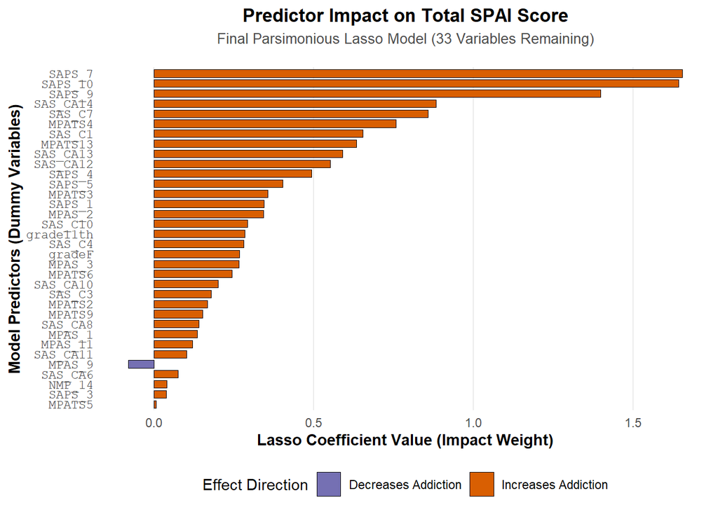

```r
# Load ggplot2 for a high-quality visualization
library(ggplot2)

# ==============================================================================
# 1. ISOLATE AND RANK THE WINNING 33 PREDICTORS
# ==============================================================================
# MODIFIED: Pulls from top_predictors_1se to capture the 33-variable model
final_ranked_predictors <- top_predictors_1se %>%
  filter(Dummy_Variable != "(Intercept)", Coefficient != 0) %>%
  # Recalculate absolute impact to ensure proper ranking execution
  mutate(Absolute_Impact = abs(Coefficient)) %>%
  arrange(desc(Absolute_Impact)) %>%
  dplyr::select(Original_Variable, Dummy_Variable, Coefficient, Absolute_Impact)

# # Print the full ranked list to your console
# cat("\n==================================================================\n")
# cat("          FINAL RANKED PREDICTORS (LAMBDA 1SE MODEL)               \n")
# cat("==================================================================\n")
# print(final_ranked_predictors, n = Inf, row.names = FALSE)

# MODIFIED: Saved with a unique filename specific to this final 33-variable set
write.csv(final_ranked_predictors, "total_spai_final_33_predictors.csv", row.names = FALSE)

# ==============================================================================
# 2. GENERATE A COEFFICIENT IMPACT VISUALIZATION
# ==============================================================================
# Create a clear color flag for positive vs. negative coefficients
plot_df <- final_ranked_predictors %>%
  mutate(
    Direction = ifelse(Coefficient > 0, "Increases Addiction", "Decreases Addiction"),
    # Reorder the dummy variables so the chart ranks them from largest to smallest impact
    Dummy_Variable = reorder(Dummy_Variable, Absolute_Impact)
  )

# Build the publication-ready bar chart with centered titles
coef_plot <- ggplot(plot_df, aes(x = Dummy_Variable, y = Coefficient, fill = Direction)) +
  geom_bar(stat = "identity", width = 0.75, color = "black", linewidth = 0.2) +
  coord_flip() +
  scale_fill_manual(values = c("Increases Addiction" = "#d95f02", "Decreases Addiction" = "#7570b3")) +
  labs(
    title = "Predictor Impact on Total SPAI Score",
    subtitle = "Final Parsimonious Lasso Model (33 Variables Remaining)",
    x = "Model Predictors (Dummy Variables)",
    y = "Lasso Coefficient Value (Impact Weight)",
    fill = "Effect Direction"
  ) +
  theme_minimal(base_size = 11) +
  theme(
    # FIXED: Added hjust = 0.5 to perfectly center the title and subtitle
    plot.title = element_text(face = "bold", size = 13, hjust = 0.5, margin = margin(b = 5)),
    plot.subtitle = element_text(color = "gray30", size = 10, hjust = 0.5, margin = margin(b = 15)),
    axis.text.y = element_text(size = 9, family = "mono"),
    axis.title = element_text(face = "bold"),
    legend.position = "bottom",
    panel.grid.minor = element_blank(),
    panel.grid.major.y = element_blank()
  )


# Display the plot in your RStudio viewer
print(coef_plot)
```

After performing the lasso regression and reducing the model to only 19 variables, additional analysis continued. With the optimal model containing 33 questions that can be used to predict cellphone addiction, Ordinary Least Squares was applied to just the top five influential predictor variables from the 33 Variable Lasso Regression model as well as the 52 lambda.min Lasso Regression model as the results from that model were very close to the 33 variable model. An interesting observation is that the top five variables from the 52 lambda.min model were the exact same top five as the 22 variable model.

Here is a table that summarizes the results of all models:

```r
 #==============================================================================
# 1. ISOLATE TARGET AND SELECTED PREDICTORS (TOP 5 OF 22 CONFIGURATION)
# ==============================================================================
# Define the precise 5 features for the updated configuration
selected_vars_top5_22 <- c("SAPS_10", "SAPS_7", "MPATS4", "SAPS_9", "SAS_CA14")

# Extract features from your base dataframe
x_ols_df_22 <- cells_data %>% dplyr::select(all_of(selected_vars_top5_22))

# Split the isolated feature space into matching Train/Test matrices
# using your script's active training split index
x_train_ols_22 <- x_ols_df_22[train_index, ]
x_test_ols_22  <- x_ols_df_22[-train_index, ]

# Combine with target arrays into clean training data frames for lm()
train_data_ols_22 <- data.frame(y = y_train, x_train_ols_22)
test_data_ols_22  <- data.frame(y = y_test, x_test_ols_22)

# ==============================================================================
# 2. FIT THE MULTIPLE LINEAR REGRESSION (OLS) MODEL
# ==============================================================================
ols_five_model_22 <- lm(y ~ ., data = train_data_ols_22)

# # ==============================================================================
# 3. EVALUATE MODEL PERFORMANCE METRICS
# ==============================================================================
# Generate numeric vector predictions for test and training pools
pred_train_ols5_22 <- as.numeric(predict(ols_five_model_22, newdata = train_data_ols_22))
pred_test_ols5_22  <- as.numeric(predict(ols_five_model_22, newdata = test_data_ols_22))

# Calculate Core Error metrics
rmse_tr_ols5_22 <- sqrt(mean((y_train - pred_train_ols5_22)^2))
rmse_te_ols5_22 <- sqrt(mean((y_test - pred_test_ols5_22)^2))
mae_tr_ols5_22  <- mean(abs(y_train - pred_train_ols5_22))
mae_te_ols5_22  <- mean(abs(y_test - pred_test_ols5_22))
r2_tr_ols5_22   <- 1 - (sum((y_train - pred_train_ols5_22)^2) / sum((y_train - mean(y_train))^2))
r2_te_ols5_22   <- 1 - (sum((y_test - pred_test_ols5_22)^2) / sum((y_test - mean(y_test))^2))

# Calculate Context Metrics
range_y_test              <- max(y_test) - min(y_test)
norm_mae_test_ols5_22     <- (mae_te_ols5_22 / range_y_test) * 100
mape_test_ols5_22         <- mean(abs((y_test - pred_test_ols5_22) / y_test)) * 100

# ==============================================================================
# 4. PRINT FORMATTED PERFORMANCE RESULTS (EXCLUDING OPTIMAL LAMBDA)
# ==============================================================================
ols5_22_results_horizontal <- data.frame(
  Model = "Top_5_of_22_Model", # MODIFIED
  OVR = length(selected_vars_top5_22),
  `Train RMSE` = round(rmse_tr_ols5_22, 4),
  `Test RMSE`  = round(rmse_te_ols5_22, 4),
  `Train MAE`   = round(mae_tr_ols5_22, 4),
  `Test MAE`    = round(mae_te_ols5_22, 4),
  `Train R-Squared` = round(r2_tr_ols5_22, 4),
  `Test R-Squared`  = round(r2_te_ols5_22, 4),
  `Test Norm MAE (%)` = round(norm_mae_test_ols5_22, 2),
  `Test MAPE (%)`     = round(mape_test_ols5_22, 2),
  check.names = FALSE
)

# ==============================================================================
# 1. ISOLATE TARGET AND SELECTED PREDICTORS (MPATS4 EXCLUDED, SAS_C7 ADDED)
# ==============================================================================
# Define the precise 5 features for the updated configuration
selected_vars_new5 <- c("SAPS_10", "SAPS_7", "SAPS_9", "SAS_CA14", "SAS_C7")

# Extract features from your base dataframe
x_ols5_new_df <- cells_data %>% dplyr::select(all_of(selected_vars_new5))

# Split the isolated feature space into matching Train/Test matrices
# using your script's active training split index
x_train_ols5_new <- x_ols5_new_df[train_index, ]
x_test_ols5_new  <- x_ols5_new_df[-train_index, ]

# Combine with target arrays into clean training data frames for lm()
train_data_ols5_new <- data.frame(y = y_train, x_train_ols5_new)
test_data_ols5_new  <- data.frame(y = y_test, x_test_ols5_new)

# ==============================================================================
# 2. FIT THE MULTIPLE LINEAR REGRESSION (OLS) MODEL
# ==============================================================================
ols_five_new_model <- lm(y ~ ., data = train_data_ols5_new)


# ==============================================================================
# 3. EVALUATE MODEL PERFORMANCE METRICS
# ==============================================================================
# Generate numeric vector predictions for test and training pools
pred_train_ols5_new <- as.numeric(predict(ols_five_new_model, newdata = train_data_ols5_new))
pred_test_ols5_new  <- as.numeric(predict(ols_five_new_model, newdata = test_data_ols5_new))

# Calculate Core Error metrics
rmse_tr_ols5_new <- sqrt(mean((y_train - pred_train_ols5_new)^2))
rmse_te_ols5_new <- sqrt(mean((y_test - pred_test_ols5_new)^2))
mae_tr_ols5_new  <- mean(abs(y_train - pred_train_ols5_new))
mae_te_ols5_new  <- mean(abs(y_test - pred_test_ols5_new))
r2_tr_ols5_new   <- 1 - (sum((y_train - pred_train_ols5_new)^2) / sum((y_train - mean(y_train))^2))
r2_te_ols5_new   <- 1 - (sum((y_test - pred_test_ols5_new)^2) / sum((y_test - mean(y_test))^2))

# Calculate Context Metrics
range_y_test           <- max(y_test) - min(y_test)
norm_mae_test_ols5_new <- (mae_te_ols5_new / range_y_test) * 100
mape_test_ols5_new     <- mean(abs((y_test - pred_test_ols5_new) / y_test)) * 100

# ==============================================================================
# 4. PRINT FORMATTED PERFORMANCE RESULTS (EXCLUDING OPTIMAL LAMBDA FOR OLS)
# ==============================================================================
ols5_new_results_horizontal <- data.frame(
  Model = "Top_5_of_33_Model", # MODIFIED
  OVR = length(selected_vars_new5),
  `Train RMSE` = round(rmse_tr_ols5_new, 4),
  `Test RMSE`  = round(rmse_te_ols5_new, 4),
  `Train MAE`   = round(mae_tr_ols5_new, 4),
  `Test MAE`    = round(mae_te_ols5_new, 4),
  `Train R-Squared` = round(r2_tr_ols5_new, 4),
  `Test R-Squared`  = round(r2_te_ols5_new, 4),
  `Test Norm MAE (%)` = round(norm_mae_test_ols5_new, 2),
  `Test MAPE (%)`     = round(mape_test_ols5_new, 2),
  check.names = FALSE
)
# ==============================================================================
# FINAL MASTER SPECIFICATION CONSOLIDATION (WEBSITE HTML FORMAT)
# ==============================================================================

library(knitr)
library(kableExtra)

mega_dynamic_comparison <- data.frame(
  Model = c(
    "Baseline",
    "LASSO 1",
    "LASSO 2",
    "Lambda 1SE",
    "Strict",
    "Ultra",
    "Terminal",
    "Top 5 (33)",
    "Top 5 (52/22)"
  ),
  Predictors = c(81, 52, 52, 33, 28, 22, 19, 5, 5),
  `Test RMSE` = c(5.2338, 5.1702, 5.2142, 5.1626, 5.2553, 5.5280, 5.8296, 6.0199, 6.2256),
  `Test MAE` = c(3.9987, 3.9714, 3.9902, 3.9910, 4.1075, 4.1075, 4.6312, 4.7114, 4.8361),
  `Test R²` = c(0.7429, 0.7491, 0.7448, 0.7498, 0.7407, 0.7131, 0.6810, 0.6598, 0.6362),
  `Norm MAE (%)` = c(7.41, 7.35, 7.39, 7.39, 7.61, 8.06, 8.58, 8.72, 8.96),
  `MAPE (%)` = c(10.59, 10.58, 10.60, 10.71, 11.21, 12.14, 13.08, 12.65, 12.91),
  stringsAsFactors = FALSE
)


# ==============================================================================
# WEBSITE HTML TABLE
# ==============================================================================

mega_dynamic_comparison %>%
  kable(
    format = "html",
    digits = 3,
    caption = "OLS and LASSO Model Performance Comparison (Total SPAI)"
  ) %>%
  kable_styling(
    bootstrap_options = c(
      "striped",
      "hover",
      "responsive"
    ),
    full_width = TRUE,
    position = "center",
    font_size = 14
  )
```

OLS and LASSO Model Performance Comparison (Total SPAI)

| Model | Predictors | Test.RMSE | Test.MAE | Test.R. | Norm.MAE.... | MAPE.... |
| --- | --- | --- | --- | --- | --- | --- |
| Baseline | 81 | 5.234 | 3.999 | 0.743 | 7.41 | 10.59 |
| LASSO 1 | 52 | 5.170 | 3.971 | 0.749 | 7.35 | 10.58 |
| LASSO 2 | 52 | 5.214 | 3.990 | 0.745 | 7.39 | 10.60 |
| Lambda 1SE | 33 | 5.163 | 3.991 | 0.750 | 7.39 | 10.71 |
| Strict | 28 | 5.255 | 4.108 | 0.741 | 7.61 | 11.21 |
| Ultra | 22 | 5.528 | 4.108 | 0.713 | 8.06 | 12.14 |
| Terminal | 19 | 5.830 | 4.631 | 0.681 | 8.58 | 13.08 |
| Top 5 (33) | 5 | 6.020 | 4.711 | 0.660 | 8.72 | 12.65 |
| Top 5 (52/22) | 5 | 6.226 | 4.836 | 0.636 | 8.96 | 12.91 |

Both models with only five variables performed very well with the top five variables from the 33 variable model accounting for 65.98% of the variances of unseen data which is remarkable high for a real model using only five variables.  
This study substantiates that if you were only able to conduct a short, five question survey, that the five questions that you should ask are:

1. Even when I think I should stop using my mobile phone, I will continue to use it and cannot stop.
2. It has become a habit of me to spend a lot of time on my mobile phone.
3. I feel very panic when I can’t use my mobile phone.
4. I don’t get enough sleep and feel tired from using mobile phone too much.
5. Playing mobile phone has affected my academic performance.

These questions are the strongest indicator of cell phone addiction.

## Conclusion

This study applied iterative LASSO variable reduction to a Chinese Computer Adaptive Testing item bank on problematic mobile phone use (Gao et al. 2024) in order to predict continuous SPAI total severity from non-SPAI instrument items and demographics, with SPAI items excluded from the predictor set to avoid circularity. Beginning with 81 candidates, Phase 1 selection at `lambda.min` retained 52 predictors; Phase 2 escalation to `lambda.1se` yielded a 33-predictor model that achieved the most favorable balance of test error and complexity. That preferred specification attained a test RMSE of 5.16 and a test $R^2$ of 0.75 on held-out respondents, corresponding to an approximate 59% reduction in predictor count relative to the full baseline. Further shrinkage to 28, 22, and 19 predictors degraded predictive accuracy—with test $R^2$ falling below 0.70 at 19 predictors—and therefore activated the stopping rule.

Selected items concentrated in SAPS (addiction proneness) and SAS (cognitive and behavioral addiction symptoms), with a smaller contribution from MPATS; NMP (nomophobia) items were largely driven to zero, consistent with nomophobia’s weaker zero-order association with SPAI total. A post-LASSO ordinary least squares refit on the five largest-magnitude items retained a test $R^2$ of 0.66—well below the 33-item model’s 0.75, yet still high for a five-item instrument. Those five items capture compulsive use, habitual time spent, panic upon separation, sleep loss, and impaired academic performance, spanning loss of control, salience, withdrawal, and life interference.

The elevated $R^2$ is most appropriately interpreted as convergent validity among overlapping addiction instruments rather than as evidence of causal effects (Gao et al. 2024; Lin et al. 2014; James et al. 2013). Inter-scale correlations frequently exceeding $r = 0.60$ produce the multicollinearity that motivated LASSO over unregularized ordinary least squares (McNeish 2015). Because the sample was collected in China among predominantly young adults (mean age $= 18.8$ years) and contained more female than male respondents, the findings should not be generalized to other populations without external validation (Gao et al. 2024). Practically, the 33-item LASSO model—and, where brevity is essential, the five-item OLS subset—can estimate SPAI-like severity without administering the full multi-instrument battery, subject to prospective validation.

Future work should assess robustness across alternative train–test splits and random seeds, validate the short-form item sets in independent samples, pursue group LASSO more systematically—including alternative scale-defined groupings and penalty schedules relative to the iterative plain LASSO path—and extend the analysis beyond the Chinese young-adult cohort in order to distinguish context-specific from more universal predictors of smartphone addiction severity.

## References

Busch, Peter André, and Stephen McCarthy. 2021. “Antecedents and Consequences of Problematic Smartphone Use: A Systematic Literature Review of an Emerging Research Area.” *Computers in Human Behavior* 114: 106414. https://doi.org/10.1016/j.chb.2020.106414.

Dalalyan, Arnak S., Mohamed Hebiri, and Johannes Lederer. 2017. “On the Prediction Performance of the Lasso.” *Bernoulli* 23 (1): 552–81.

Efron, Bradley, Trevor Hastie, Iain Johnstone, and Robert Tibshirani. 2004. “Least Angle Regression.” *The Annals of Statistics* 32 (2): 407–51. https://doi.org/10.1214/009053604000000067.

Gao, Yaojie, Xiaorui Liu, Zhao Zhou, Miao Chao, and Tour Liu. 2024. “Data for Developing Computerized Adaptive Testing of Problematic Mobile Phone Use.” *Data in Brief* 55: 110746. https://doi.org/10.1016/j.dib.2024.110746.

Hesterberg, Tim, Nam H. Choi, Lukas Meier, and Chris Fraley. 2008. “Least Angle and $\ell_1$ Penalized Regression: A Review.” *Statistics Surveys* 2: 61–93. https://doi.org/10.1214/08-SS035.

Hoerl, Arthur E., and Robert W. Kennard. 1970. “Ridge Regression: Biased Estimation for Nonorthogonal Problems.” *Technometrics* 12 (1): 55–67.

Huang, Yue, Tobias D. Tibbe, Ning Tang, and Amanda K. Montoya. 2024. “Lasso and Group Lasso with Categorical Predictors: Impact of Coding Strategy on Variable Selection and Prediction.” *Journal of Behavioral Data Science* 4 (1).

James, Gareth, Daniela Witten, Trevor Hastie, and Robert Tibshirani. 2013. *An Introduction to Statistical Learning*. Springer. https://doi.org/10.1007/978-1-4614-7138-7.

Lin, Yu-Hsuan, Li-Ren Chang, Yun-Hsuan Lee, Hsiang-Wei Tseng, Terry B. J. Kuo, and Sheng-Hsuan Chen. 2014. “Development and Validation of the Smartphone Addiction Inventory (SPAI).” *PLoS ONE* 9 (6): e98312. https://doi.org/10.1371/journal.pone.0098312.

McNeish, Daniel M. 2015. “Using LASSO for Predictor Selection and to Assuage Overfitting: A Method Long Overlooked in Behavioral Sciences.” *Multivariate Behavioral Research* 50 (5): 471–84.

Santosa, Fadil, and William W. Symes. 1986. “Linear Inversion of Band-Limited Reflection Seismograms.” *SIAM Journal on Scientific and Statistical Computing* 7 (4): 1307–30.

Tibshirani, Robert. 1996. “Regression Shrinkage and Selection via the Lasso.” *Journal of the Royal Statistical Society: Series B (Methodological)* 58 (1): 267–88.